# Artificial Neural Networks

Predicting the Edibility of Mushrooms

Ryan Whitell

```r
# Packages Required
library(neuralnet)  # ANN
library(onehot)     # One-hot encoding
```

# Introduction

Artificial neural networks borrow from biology. Like their namesake, artificial neural networks model the neural connections present in our own brains. Nodes in a network are connected to inputs and outputs. Whether or not the output is activated depends on the inputs, the weight on those inputs, and the activation function. Putting many nodes together results in a network that is able to represent any function. What is learned or trained in an ANN are the weights on each input.

# The Mushroom Data Set

The data set by Schlimmer (1987), retrieved from the UCI machine learning repository (Lichman, 2013), contains 8124 examples with 22 features representing 23 species of gilled mushrooms. The labels are whether the mushroom is edible or poisonous:

1. cap-shape: bell=b,conical=c,convex=x,flat=f, knobbed=k,sunken=s
2. cap-surface: fibrous=f,grooves=g,scaly=y,smooth=s
3. cap-color: brown=n,buff=b,cinnamon=c,gray=g,green=r, pink=p,purple=u,red=e,white=w,yellow=y
4. bruises?: bruises=t,no=f
5. odor: almond=a,anise=l,creosote=c,fishy=y,foul=f, musty=m,none=n,pungent=p,spicy=s
6. gill-attachment: attached=a,descending=d,free=f,notched=n
7. gill-spacing: close=c,crowded=w,distant=d
8. gill-size: broad=b,narrow=n
9. gill-color: black=k,brown=n,buff=b,chocolate=h,gray=g, green=r,orange=o,pink=p,purple=u,red=e, white=w,yellow=y
10. stalk-shape: enlarging=e,tapering=t
11. stalk-root: bulbous=b,club=c,cup=u,equal=e, rhizomorphs=z,rooted=r,missing=?
12. stalk-surface-above-ring: fibrous=f,scaly=y,silky=k,smooth=s
13. stalk-surface-below-ring: fibrous=f,scaly=y,silky=k,smooth=s
14. stalk-color-above-ring: brown=n,buff=b,cinnamon=c,gray=g,orange=o, pink=p,red=e,white=w,yellow=y
15. stalk-color-below-ring: brown=n,buff=b,cinnamon=c,gray=g,orange=o, pink=p,red=e,white=w,yellow=y
16. veil-type: partial=p,universal=u
17. veil-color: brown=n,orange=o,white=w,yellow=y
18. ring-number: none=n,one=o,two=t
19. ring-type: cobwebby=c,evanescent=e,flaring=f,large=l, none=n,pendant=p,sheathing=s,zone=z
20. spore-print-color: black=k,brown=n,buff=b,chocolate=h,green=r, orange=o,purple=u,white=w,yellow=y
21. population: abundant=a,clustered=c,numerous=n, scattered=s,several=v,solitary=y
22. habitat: grasses=g,leaves=l,meadows=m,paths=p, urban=u,waste=w,woods=d

# Exploratory Data Analysis

The purpose of exploring the data first is to get familiar with it and to see if anything is of interest.

```r
shroom <- read.csv("agaricus-lepiota.csv") # Read in the data
str(shroom)
```

```
## 'data.frame':    8124 obs. of  23 variables:
##  $ class                   : Factor w/ 2 levels "e","p": 2 1 1 2 1 1 1 1 2 1 ...
##  $ cap.shape               : Factor w/ 6 levels "b","c","f","k",..: 6 6 1 6 6 6 1 1 6 1 ...
##  $ cap.surface             : Factor w/ 4 levels "f","g","s","y": 3 3 3 4 3 4 3 4 4 3 ...
##  $ cap.color               : Factor w/ 10 levels "b","c","e","g",..: 5 10 9 9 4 10 9 9 9 10 ...
##  $ bruises                 : Factor w/ 2 levels "f","t": 2 2 2 2 1 2 2 2 2 2 ...
##  $ odor                    : Factor w/ 9 levels "a","c","f","l",..: 7 1 4 7 6 1 1 4 7 1 ...
##  $ gill.attachment         : Factor w/ 2 levels "a","f": 2 2 2 2 2 2 2 2 2 2 ...
##  $ gill.spacing            : Factor w/ 2 levels "c","w": 1 1 1 1 2 1 1 1 1 1 ...
##  $ gill.size               : Factor w/ 2 levels "b","n": 2 1 1 2 1 1 1 1 2 1 ...
##  $ gill.color              : Factor w/ 12 levels "b","e","g","h",..: 5 5 6 6 5 6 3 6 8 3 ...
##  $ stalk.shape             : Factor w/ 2 levels "e","t": 1 1 1 1 2 1 1 1 1 1 ...
##  $ stalk.root              : Factor w/ 5 levels "?","b","c","e",..: 4 3 3 4 4 3 3 3 4 3 ...
##  $ stalk.surface.above.ring: Factor w/ 4 levels "f","k","s","y": 3 3 3 3 3 3 3 3 3 3 ...
##  $ stalk.surface.below.ring: Factor w/ 4 levels "f","k","s","y": 3 3 3 3 3 3 3 3 3 3 ...
##  $ stalk.color.above.ring  : Factor w/ 9 levels "b","c","e","g",..: 8 8 8 8 8 8 8 8 8 8 ...
##  $ stalk.color.below.ring  : Factor w/ 9 levels "b","c","e","g",..: 8 8 8 8 8 8 8 8 8 8 ...
##  $ veil.type               : Factor w/ 1 level "p": 1 1 1 1 1 1 1 1 1 1 ...
##  $ veil.color              : Factor w/ 4 levels "n","o","w","y": 3 3 3 3 3 3 3 3 3 3 ...
##  $ ring.number             : Factor w/ 3 levels "n","o","t": 2 2 2 2 2 2 2 2 2 2 ...
##  $ ring.type               : Factor w/ 5 levels "e","f","l","n",..: 5 5 5 5 1 5 5 5 5 5 ...
##  $ spore.print.color       : Factor w/ 9 levels "b","h","k","n",..: 3 4 4 3 4 3 3 4 3 3 ...
##  $ population              : Factor w/ 6 levels "a","c","n","s",..: 4 3 3 4 1 3 3 4 5 4 ...
##  $ habitat                 : Factor w/ 7 levels "d","g","l","m",..: 6 2 4 6 2 2 4 4 2 4 ...
```

```r
lapply(shroom, summary)
```

```
## $class
##    e    p
## 4208 3916
##
## $cap.shape
##    b    c    f    k    s    x
##  452    4 3152  828   32 3656
##
## $cap.surface
##    f    g    s    y
## 2320    4 2556 3244
##
## $cap.color
##    b    c    e    g    n    p    r    u    w    y
##  168   44 1500 1840 2284  144   16   16 1040 1072
##
## $bruises
##    f    t
## 4748 3376
##
## $odor
##    a    c    f    l    m    n    p    s    y
##  400  192 2160  400   36 3528  256  576  576
##
## $gill.attachment
##    a    f
##  210 7914
##
## $gill.spacing
##    c    w
## 6812 1312
##
## $gill.size
##    b    n
## 5612 2512
##
## $gill.color
##    b    e    g    h    k    n    o    p    r    u    w    y
## 1728   96  752  732  408 1048   64 1492   24  492 1202   86
##
```

[output cut: 36 more lines]

```
## $ring.type
##    e    f    l    n    p
## 2776   48 1296   36 3968
##
## $spore.print.color
##    b    h    k    n    o    r    u    w    y
##   48 1632 1872 1968   48   72   48 2388   48
##
## $population
##    a    c    n    s    v    y
##  384  340  400 1248 4040 1712
##
## $habitat
##    d    g    l    m    p    u    w
## 3148 2148  832  292 1144  368  192
```

Immediately noticed is that veil type only has one factor and stock root is missing in 2480 examples. Other than that the data looks good.

# Data Preprocessing

### Drop Veil Type

The veil type is a constant, so drop it from the data set.

```r
shroom <- subset(x = shroom, select = -veil.type) # Drop veil.type column
```

### Handle Missing Values

In this case, stalk root contains many missing values. There are many different ways to handle this type of data, in this example the missing data is turned into a factor called “u” for unknown.

```r
table(shroom$stalk.root) # Inspect
```

```
##
##    ?    b    c    e    r
## 2480 3776  556 1120  192
```

```r
levels(shroom$stalk.root) <- c("u", "b", "c", "e", "r") # Convert
table(shroom$stalk.root) # Inspect
```

```
##
##    u    b    c    e    r
## 2480 3776  556 1120  192
```

# The Artificial Neural Network

### Create Numeric Data

The ANN algorithm requires all data to be numeric, including the outputs (labels).

```r
shroom_numeric <- as.data.frame(lapply(shroom, as.numeric)) # Change all rows to numeric
str(shroom_numeric)
```

```
## 'data.frame':    8124 obs. of  22 variables:
##  $ class                   : num  2 1 1 2 1 1 1 1 2 1 ...
##  $ cap.shape               : num  6 6 1 6 6 6 1 1 6 1 ...
##  $ cap.surface             : num  3 3 3 4 3 4 3 4 4 3 ...
##  $ cap.color               : num  5 10 9 9 4 10 9 9 9 10 ...
##  $ bruises                 : num  2 2 2 2 1 2 2 2 2 2 ...
##  $ odor                    : num  7 1 4 7 6 1 1 4 7 1 ...
##  $ gill.attachment         : num  2 2 2 2 2 2 2 2 2 2 ...
##  $ gill.spacing            : num  1 1 1 1 2 1 1 1 1 1 ...
##  $ gill.size               : num  2 1 1 2 1 1 1 1 2 1 ...
##  $ gill.color              : num  5 5 6 6 5 6 3 6 8 3 ...
##  $ stalk.shape             : num  1 1 1 1 2 1 1 1 1 1 ...
##  $ stalk.root              : num  4 3 3 4 4 3 3 3 4 3 ...
##  $ stalk.surface.above.ring: num  3 3 3 3 3 3 3 3 3 3 ...
##  $ stalk.surface.below.ring: num  3 3 3 3 3 3 3 3 3 3 ...
##  $ stalk.color.above.ring  : num  8 8 8 8 8 8 8 8 8 8 ...
##  $ stalk.color.below.ring  : num  8 8 8 8 8 8 8 8 8 8 ...
##  $ veil.color              : num  3 3 3 3 3 3 3 3 3 3 ...
##  $ ring.number             : num  2 2 2 2 2 2 2 2 2 2 ...
##  $ ring.type               : num  5 5 5 5 1 5 5 5 5 5 ...
##  $ spore.print.color       : num  3 4 4 3 4 3 3 4 3 3 ...
##  $ population              : num  4 3 3 4 1 3 3 4 5 4 ...
##  $ habitat                 : num  6 2 4 6 2 2 4 4 2 4 ...
```

### Split the Data Between Testing and Training

```r
set.seed(77)                                                          # Get the same data each time
idx <- sample(nrow(shroom_numeric), round(nrow(shroom_numeric)*0.7))  # Create 2 subsets with ratio 70:30
shroom_train <- shroom_numeric[idx, ]                                 # Training subset
shroom_test <- shroom_numeric[-idx, ]                                 # Testing subset
```

### Train the Model

```r
shroom_model <- neuralnet(class ~ cap.shape +
                                  cap.surface +
                                  cap.color +
                                  bruises +
                                  odor +
                                  gill.attachment +
                                  gill.spacing +
                                  gill.size +
                                  gill.color +
                                  stalk.shape +
                                  stalk.root +
                                  stalk.surface.above.ring +
                                  stalk.surface.below.ring +
                                  stalk.color.above.ring +
                                  stalk.color.below.ring +
                                  veil.color +
                                  ring.number +
                                  ring.type +
                                  spore.print.color +
                                  population +
                                  habitat,
                                  data = shroom_train)
```

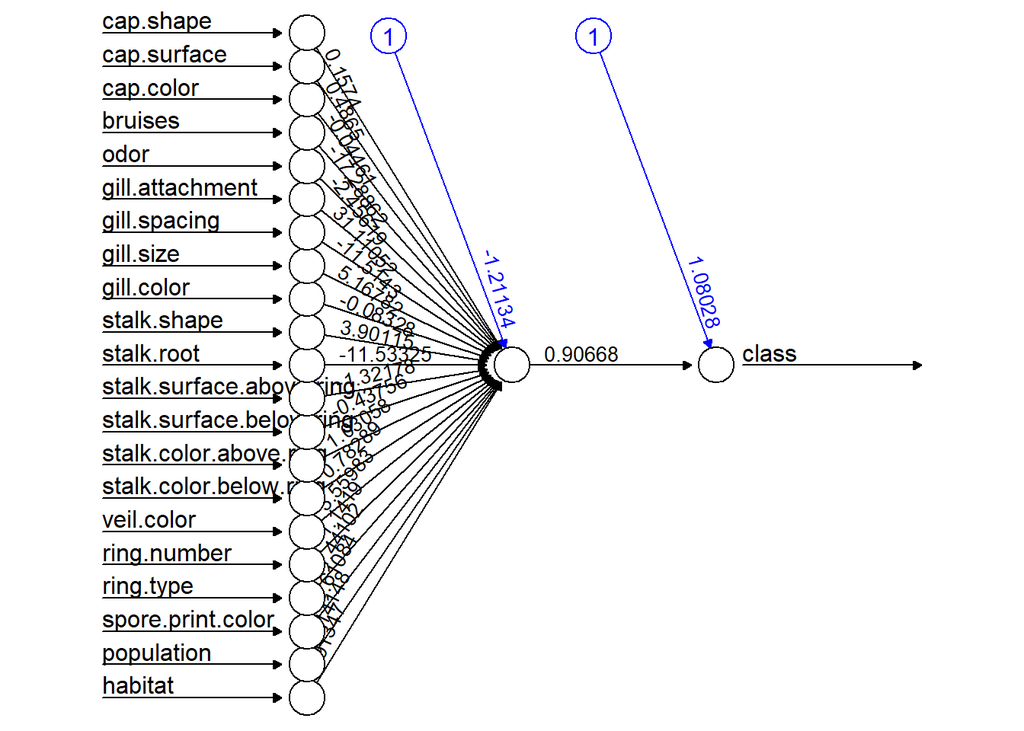

Figure 1: Simple Neural Network Architecture

```r
plot(shroom_model, rep="best")
```

### Test the Model

```r
shroom_pred <- compute(shroom_model, shroom_test[,2:ncol(shroom_test)])
```

### Evaluating Performance

The output of this ANN is not binary, so round the outputs to get the binary classification.

```r
tail(shroom_pred$net.result) # Either 'close' to 1 or 'close' to 2, not binary
```

```
##             [,1]
## 8113 1.080281568
## 8114 1.986631160
## 8117 1.986949223
## 8120 1.080284446
## 8121 1.080281548
## 8123 1.986922528
```

```r
# Returns the percentage of correct predictions
# Rounds the predictions first (non binary)
get.accuracy <- function(prediction, real) {
  prediction <- round(prediction)
  accuracy <- prediction == real
  return (length(accuracy[accuracy == TRUE])/length(accuracy))
}
```

```r
get.accuracy(shroom_pred$net.result, shroom_test$class)
```

```
## [1] 0.9417316373
```

## Tweaking Hyperparameters

There are many neural network hyperparameters or ‘knobs’ to try tweaking to get better results.

### Adjusting the Network by Adding Hidden Nodes

```r
# Returns the accuracy of a neural net with N nodes
add.hidden.nodes <- function(hidden_nodes, train, test, test_cl) {
  # Aggregate results
  n <- c()
  a <- c()

  for (nodes in hidden_nodes) {
    # Train
    model <- neuralnet(class ~ cap.shape +
                               cap.surface +
                               cap.color +
                               bruises +
                               odor +
                               gill.attachment +
                               gill.spacing +
                               gill.size +
                               gill.color +
                               stalk.shape +
                               stalk.root +
                               stalk.surface.above.ring +
                               stalk.surface.below.ring +
                               stalk.color.above.ring +
                               stalk.color.below.ring +
                               veil.color + ring.number +
                               ring.type + spore.print.color +
                               population +
                               habitat,
                               data = train,
                               hidden = nodes)

    # Test
    prediction <- compute(model, test)

    # Evaluate
    accuracy <- get.accuracy(prediction$net.result, test_cl)

    # Aggregate results
    n <- c(n, nodes)
    a <- c(a, accuracy)
  }

  return (as.data.frame(list("Nodes" = n, "Accuracy" = a)))
}
```

```r
add.hidden.nodes(c(0, 2, 4, 6), shroom_train, shroom_test[,2:ncol(shroom_test)], shroom_test$class)
```

```
##   Nodes     Accuracy
## 1     0 0.9437833402
## 2     2 0.9954862536
## 3     4 0.9934345507
## 4     6 1.0000000000
```

### Adjusting the Network by Adding a Hidden Layer

```r
# Train an ANN with 2 hidden layers
# The first layer with 4 nodes
# The second layer with 2 nodes
shroom_model_layered <- neuralnet(class ~ cap.shape +
                                  cap.surface +
                                  cap.color +
                                  bruises +
                                  odor +
                                  gill.attachment +
                                  gill.spacing +
                                  gill.size +
                                  gill.color +
                                  stalk.shape +
                                  stalk.root +
                                  stalk.surface.above.ring +
                                  stalk.surface.below.ring +
                                  stalk.color.above.ring +
                                  stalk.color.below.ring +
                                  veil.color + ring.number +
                                  ring.type + spore.print.color +
                                  population +
                                  habitat,
                                  data = shroom_train,
                                  hidden = c(4, 2))
```

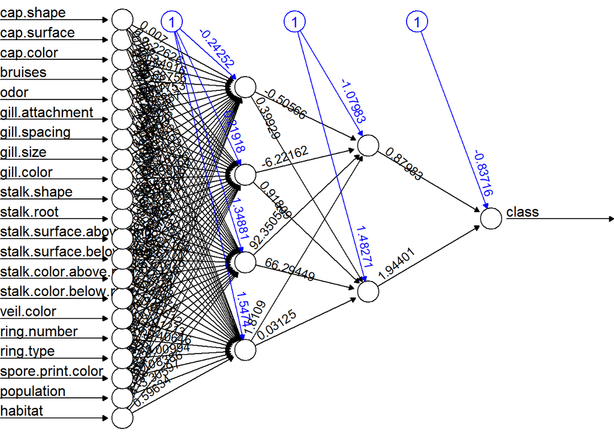

Figure 2: Neural Network Architecture with Multiple Layers

```r
plot(shroom_model_layered, rep="best")
```

```r
# Test the model
shroom_pred_layered <- compute(shroom_model_layered, shroom_test[,2:ncol(shroom_test)])

# Evaluate performance
get.accuracy(shroom_pred_layered$net.result, shroom_test$class)
```

```
## [1] 0.9417316373
```

## Improving the Input

The architecture of an ANN can also be influenced by the data. In this case, the examples in the mushroom data set contain only categorical features. Converting the data set into a sparse matrix using one-hot encoding provides another architecture to explore.

### One-Hot Encoding

```r
shroom_oh_encoding <- onehot(shroom, max_levels = 12, stringsAsFactors = TRUE) # Get the encoding
shroom_one_hot <- predict(shroom_oh_encoding, shroom) # Fill a sparse matrix
```

The `neuralnet` function requires explicitly typed features, so we can copy paste this output into the function argument.

```r
# Replace instances of '=', they confuse the nerualnet function call
colnames(shroom_one_hot) <- gsub("=", ".", colnames(shroom_one_hot))
input_names <- paste(names(shroom_one_hot[1,]), collapse = " + ")
input_names # View the output that can be used by neuralnet function
```

```
## [1] "class.e + class.p + cap.shape.b + cap.shape.c + cap.shape.f + cap.shape.k + cap.shape.s + cap.shape.x + cap.surface.f + cap.surface.g + cap.surface.s + cap.surface.y + cap.color.b + cap.color.c + cap.color.e + cap.color.g + cap.color.n + cap.color.p + cap.color.r + cap.color.u + cap.color.w …
```

### Split the Data Between Testing and Training

```r
shroom_train_sparse <- shroom_one_hot[idx, ]   # Training subset
shroom_test_sparse <- shroom_one_hot[-idx, ]   # Testing subset
```

### Train the Model

Here, we are ignoring the class.p column because it does not provide any extra information. If the output is close to 1, it will be edible. If the output is closer to 0, it will be poisonous. Plotting this network would look messy with `ncol(shroom_test) - 2 = 116` inputs, so it is omitted.

```r
shroom_model_sparse <- neuralnet(class.e ~ cap.shape.b + cap.shape.c + cap.shape.f + cap.shape.k + cap.shape.s + cap.shape.x + cap.surface.f + cap.surface.g + cap.surface.s + cap.surface.y + cap.color.b + cap.color.c + cap.color.e + cap.color.g + cap.color.n + cap.color.p + cap.color.r + cap.color.u + cap.color.w + cap.color.y + bruises.f + bruises.t + odor.a + odor.c + odor.f + odor.l + odor.m + odor.n + odor.p + odor.s + odor.y + gill.attachment.a + gill.attachment.f + gill.spacing.c + gill.spacing.w + gill.size.b + gill.size.n + gill.color.b + gill.color.e + gill.color.g + gill.color.h + gill.color.k + gill.color.n + gill.color.o + gill.color.p + gill.color.r + gill.color.u + gill.color.w + gill.color.y + stalk.shape.e + stalk.shape.t + stalk.root.u + stalk.root.b + stalk.root.c + stalk.root.e + stalk.root.r + stalk.surface.above.ring.f + stalk.surface.above.ring.k + stalk.surface.above.ring.s + stalk.surface.above.ring.y + stalk.surface.below.ring.f + stalk.surface.below.ring.k + stalk.surface.below.ring.s + stalk.surface.below.ring.y + stalk.color.above.ring.b + stalk.color.above.ring.c + stalk.color.above.ring.e + stalk.color.above.ring.g + stalk.color.above.ring.n + stalk.color.above.ring.o + stalk.color.above.ring.p + stalk.color.above.ring.w + stalk.color.above.ring.y + stalk.color.below.ring.b + stalk.color.below.ring.c + stalk.color.below.ring.e + stalk.color.below.ring.g + stalk.color.below.ring.n + stalk.color.below.ring.o + stalk.color.below.ring.p + stalk.color.below.ring.w + stalk.color.below.ring.y + veil.color.n + veil.color.o + veil.color.w + veil.color.y + ring.number.n + ring.number.o + ring.number.t + ring.type.e + ring.type.f + ring.type.l + ring.type.n + ring.type.p + spore.print.color.b + spore.print.color.h + spore.print.color.k + spore.print.color.n + spore.print.color.o + spore.print.color.r + spore.print.color.u + spore.print.color.w + spore.print.color.y + population.a + population.c + population.n + population.s + population.v + population.y + habitat.d + habitat.g + habitat.l + habitat.m + habitat.p + habitat.u + habitat.w, data = shroom_train_sparse)
```

### Test the Model

```r
shroom_pred_sparse <- compute(shroom_model_sparse, shroom_test_sparse[,3:ncol(shroom_test_sparse)])
```

### Evaluating Performance

```r
get.accuracy(shroom_pred_sparse$net.result, shroom_test_sparse[,1])
```

```
## [1] 1
```

# Conclusion

Artificial Neural Networks have many hyperparameters to tune. Also, there are many different possible architectures. The data can also effect the results of an ANN, depending on their form. The complexity and flexibility of ANNs make them suited for many different types of machine learning problems. But the complexity also makes them more difficult and time consuming to work with.

# References

Lichman, M. (2013). UCI machine learning repository. University of California, Irvine, School of Information and Computer Sciences. Retrieved from http://archive.ics.uci.edu/ml

Schlimmer, J. (1987). Mushroom records drawn from the audubon society field guide to north american mushrooms: Alfred a. knopf. *GH Lincoff (Pres.), New York*. Retrieved from http://archive.ics.uci.edu/ml/datasets/Mushroom